# MA304 Coursework Assignment

REG NO: 1905146

# Introduction

For this assignment we are given a data set containing various policing and crime statistics in Dallas 2016 and are tasked with analysing and interpreting the data set.

I have split this report into 4 sections in the first section I will analyse some initial preliminary findings of the data set; in the second section I will analyse the different types of crimes and rates in Dallas against different factors such as race and location; in the third section I will analyse the data to see if there is any discrimination in policing by looking at different factors such as suspect race and incident reason and for the last section I will analyse the Use of Force (UOF) incidents and look at the different factors for the type of UOF used.

# Preliminary Findings

We first begin by loading up the data set and setting up our working directory. (I have swapped the first and second rows of the original .csv file since the information in the second row is useless and is more convenient to plot by skipping the new first row).

```r
setwd("~/R/r scripts")
mydata = read.csv("37-00049_UOF-P_2016_prepped.csv", skip = 1, header=TRUE)
```

We can make several preliminary findings with bar plots below:

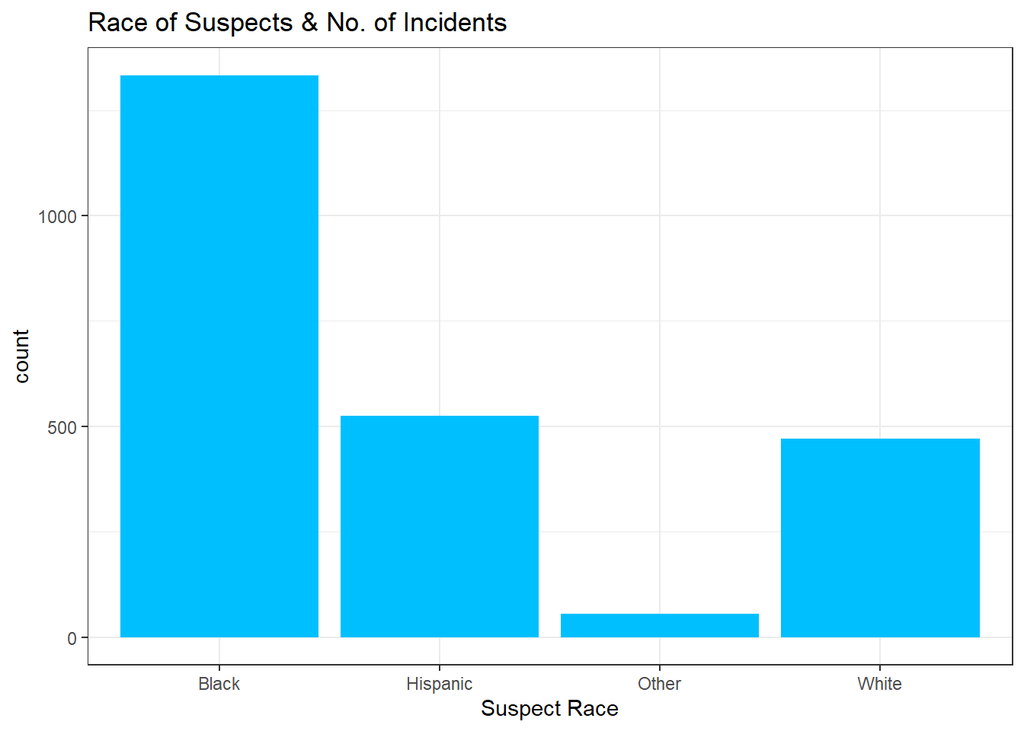

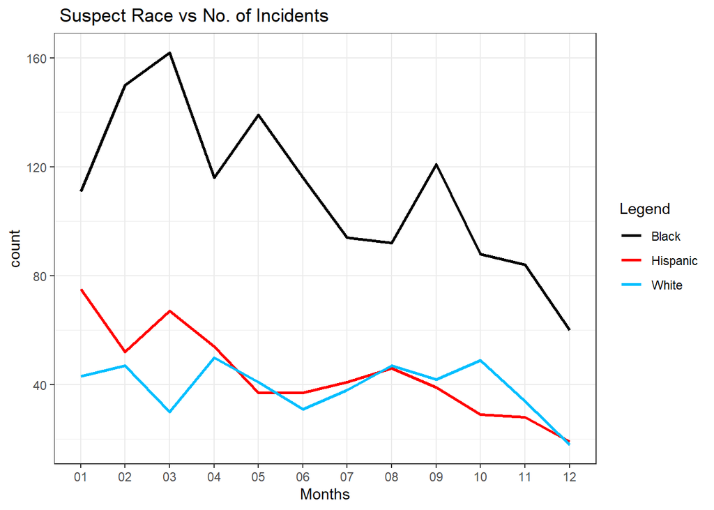

```
##  Female    Male    NULL Unknown
##     440    1932      10       1
```

```
## American Ind        Asian        Black     Hispanic         NULL        Other
##            1            5         1333          524           39           11
##        White
##          470
```

From the bar plot above we can see the ethnicities of the suspects that had an incident with the police. Looking at the bar plot we can see that suspects that were Black had an overwhelming number of incidents compared to Hispanic and White suspects and other races which were negligible. From the time series plot above we can see that there is a general trend of the number of incidents decreasing till the end of the year with different peaks throughout the year but with all three races having their lowest count of incidents in December.

Using the *summary()* function we are able to see more specifically that there were 1333 black suspects that had an incident with the police which is more than the combined total of hispanic and white suspects at 524 and 470 respectively. We can also see from the plot and the *summary()* function that majority of the suspects were male with 1492 more male suspects having an incident with the police compared to females.

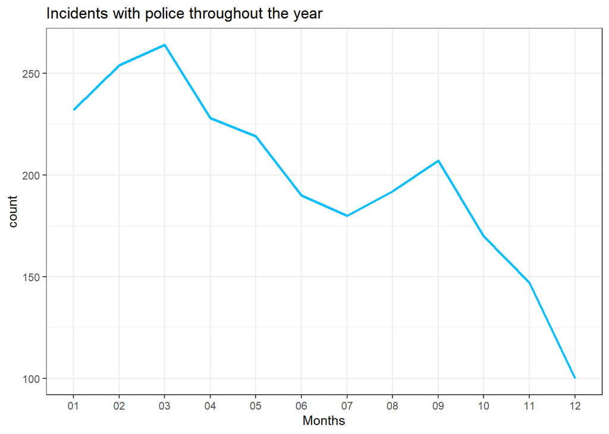

From the plot above we can see that there is a peak in the number of incidents in March with a general trend of it decreasing with a small peak in September till reaching its lowest count at the end of the year in December. This follows the same general trend as the previous time series of the number of incidents against race.

We can start to look more specifically to suspects that were arrested or not arrested using the same bar plot above.

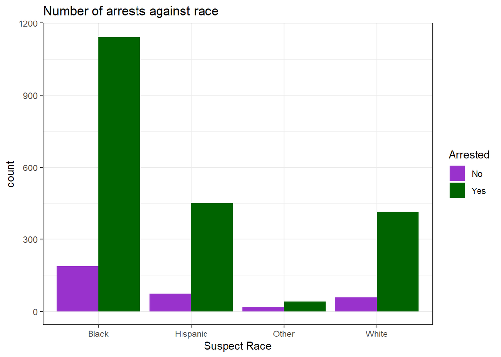

```
##   No  Yes
##  335 2048
```

From the bar plot above we can still see that Black suspects are still overwhelmingly arrested more than Hispanic and White suspects.

We can look for a general overview of the police force in this data set by looking at make up of the force by race and gender.

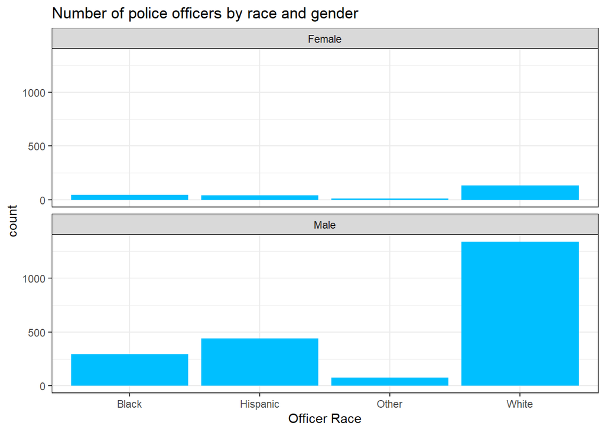

```
## American Ind        Asian        Black     Hispanic        Other        White
##            8           55          341          482           27         1470
```

```
## Female   Male
##    240   2143
```

From the plot above we can see that police force in this data set is made up of predominantly male officers and that a large majority of police officers are White followed by Hispanic then Black police officers.

To analyse the crime rate in Dallas I have split the types of crimes into 5 categories: **Violent Crime**, **Drug Crime**, **Property Crime**, **Traffic Crime** and **Misdemeanors**. To look at the rate of violent crime in Dallas I have reduced the variety of the crimes due to the large amount of similar iterations for assault and will do a similar process for the other crime categories. I will also create new columns for the different crime categories to make it easier to create plots.

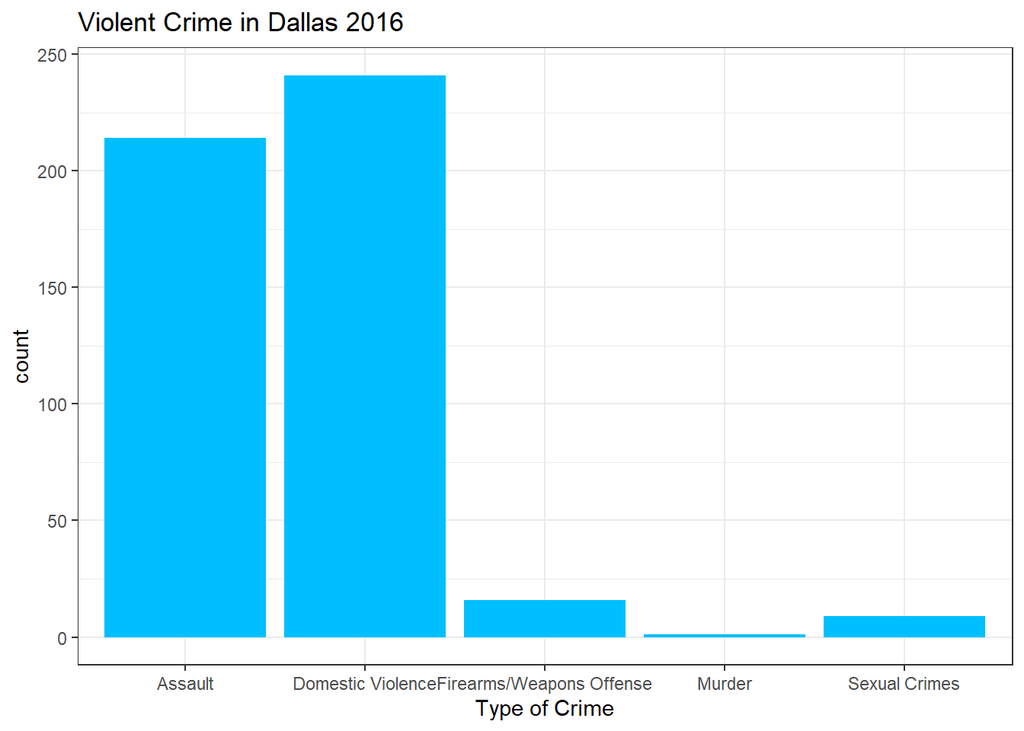

From the bar plot above we can see the rate of violent crime in Dallas with Domestic Violence and Assault being the most frequent cases of violent crime with Murder and Sexual Crimes being among the lowest.

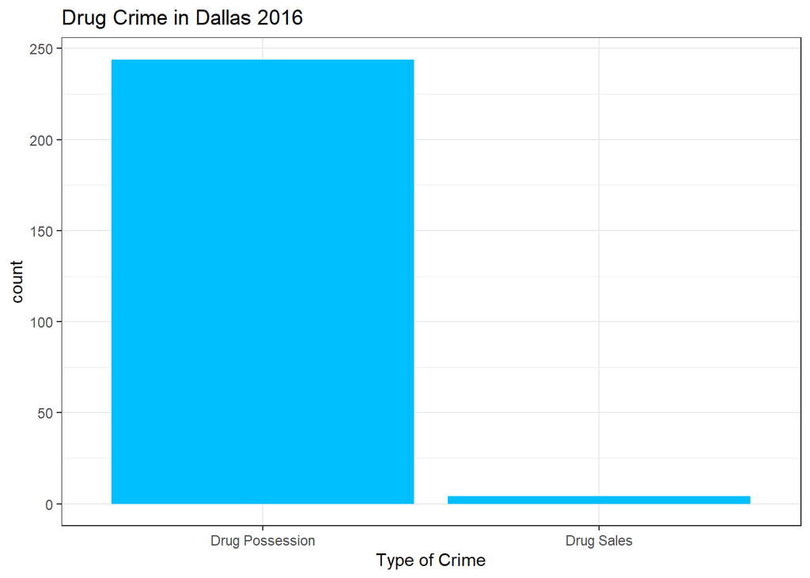

From the bar plot above we can see that Drug Possession makes up the majority of the drug crime in Dallas with Drug Sales taking up a small minority.

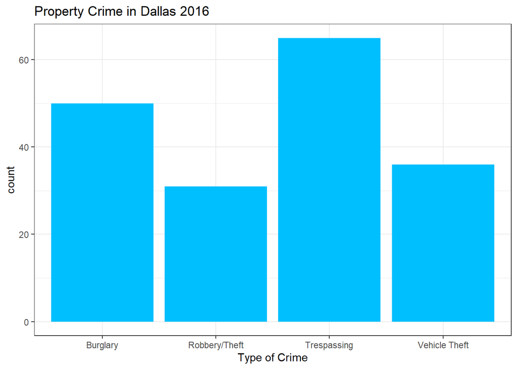

From the bar plot above we can see that Trespassing is the highest type of Property Crime with Burglary and Vehicle Theft being second and third and Robbery/Theft last.

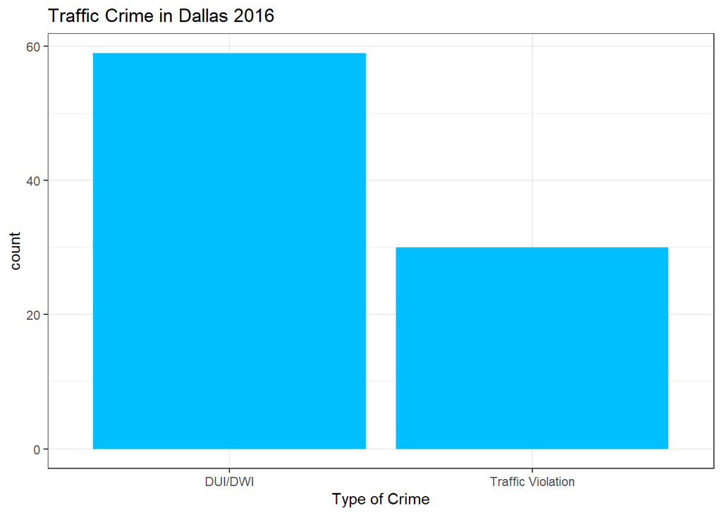

From the bar plot above we can see that DUI/DWI is the most frequent case of Traffic Crime, occurring nearly twice as much as Traffic Violations.

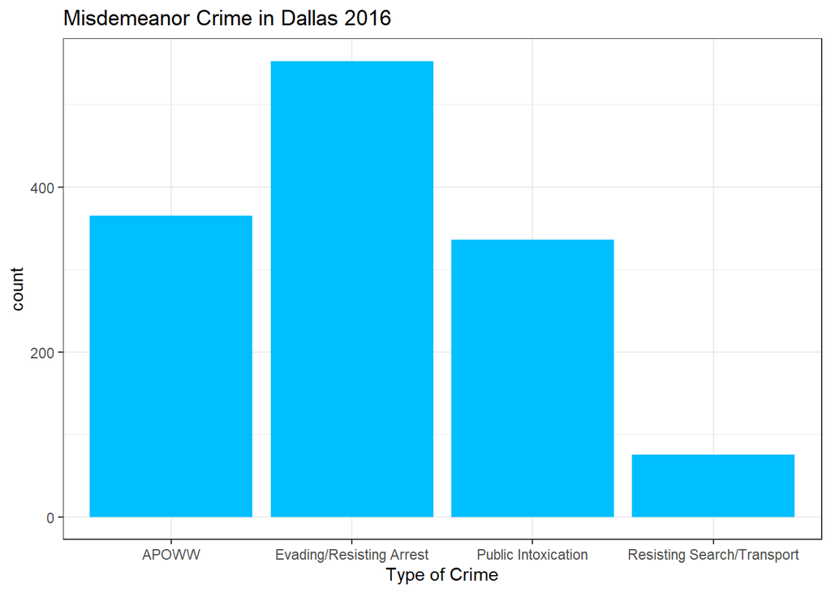

From the bar plot above we can see that Evading/Resisting Arrest is the highest type of Misdemeanor Crime followed by APOWW (Apprehension by Peace Officer Without Warrant - where people are detained by a police officer without warrant for a mental health evaluation) at second place and Public Intoxication and Resisting Search/Transport at third and fourth respectively.

# A Closer Look: Violent Crime in Dallas

We can take a closer look at violent crime in Dallas by looking at the geographical locations of where violent crime has taken place.

[interactive chart not shown]

From the map above and filtering out the other types of crime we can see that Domestic Violence (the highest case of violent crime in the data set) is largely taking place in the outskirts of the city centre in the suburban areas with some taking place in the city centre.

Looking at Assault (the second highest case of violent crime) you can see it largely being concentrated in central Dallas with a small minority in the suburban outskirts.

For the remaining crimes there is not enough data to gauge some sort of pattern in the geographical location where the crime has taken place.

We can look at where violent crime is more concentrated by breaking it down to the different divisions in the city.

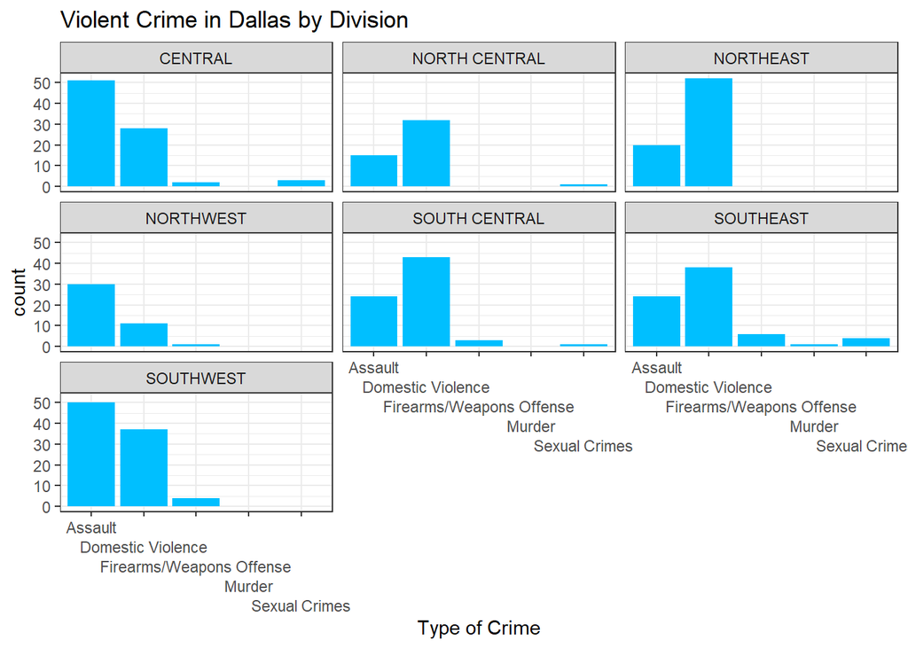

From the plot above we can see that the western part of the city (CENTRAL, NORTHWEST and SOUTHWEST) have the highest cases for Assault and the eastern parts (NORTH CENTRAL, SOUTH CENTRAL, NORTHEAST, and SOUTHEAST) have the highest cases of Domestic Violence.

We can also look at rates of violent crime broken down by the race of the suspects.

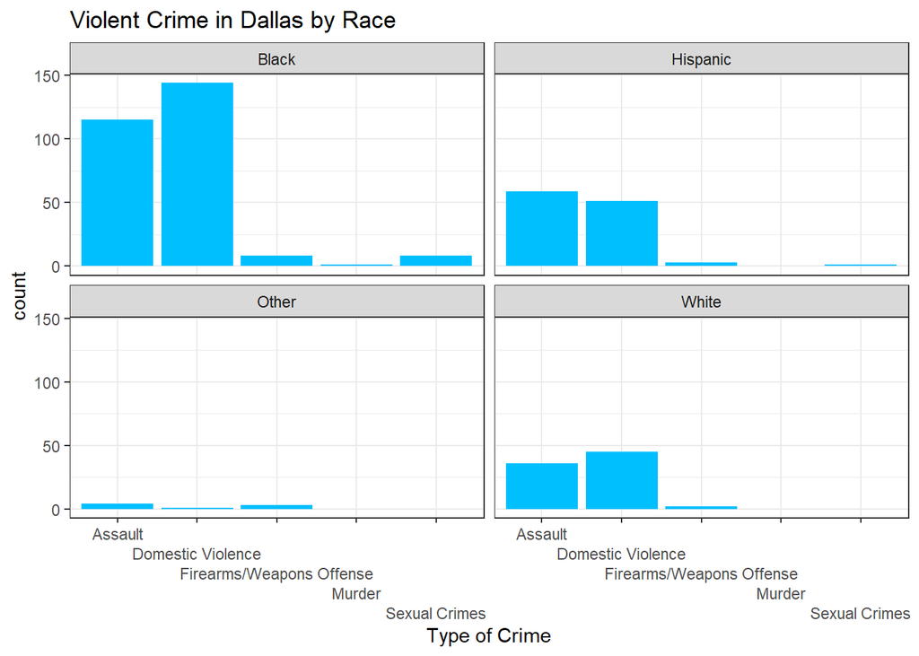

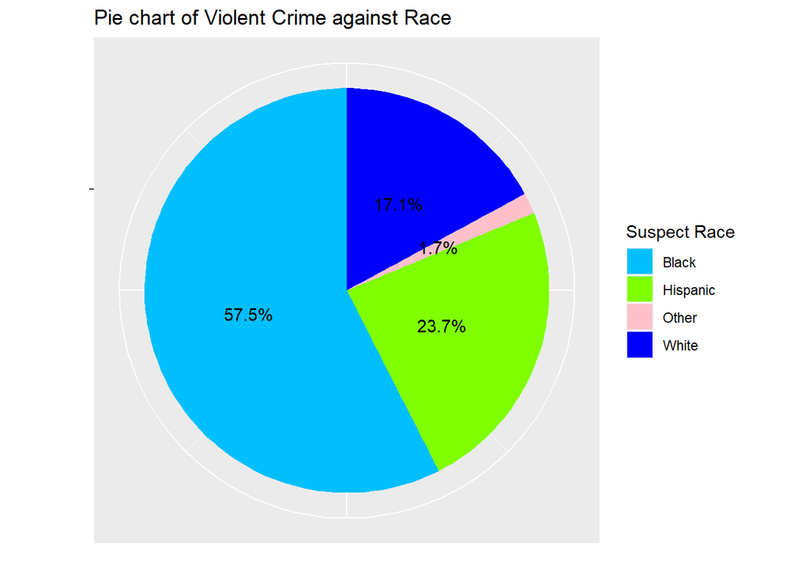

From the bar plot above we can see that Black suspects are by far the biggest perpetrators of Assault and Domestic Violence by having the highest count in the data set and are then followed by Hispanic and White suspects.

From the pie chart above we can see that Black suspects have the biggest count of Violent Crime proportionally at 57.5% followed by Hispanic suspects and White suspects at 23.7% and 17.1% respectively with the remaining races at 1.7%.

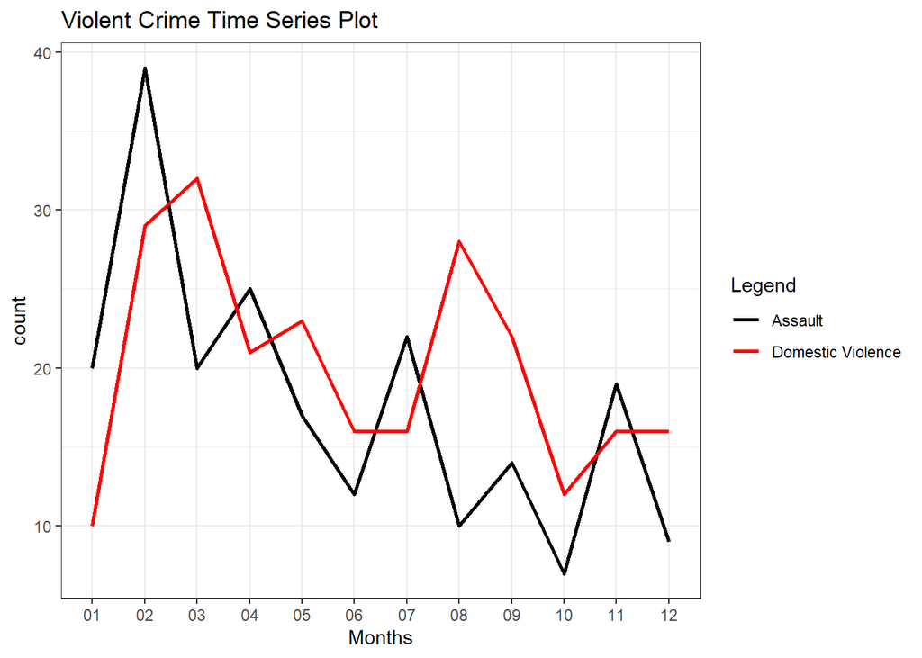

From the plot above we can see that for the highest type of Violent Crime in Dallas (Domestic Violence & Assault) that they both peak near the beginning of the year and start to decrease and forming a small peak in the summer till decreasing again to the end of the year.

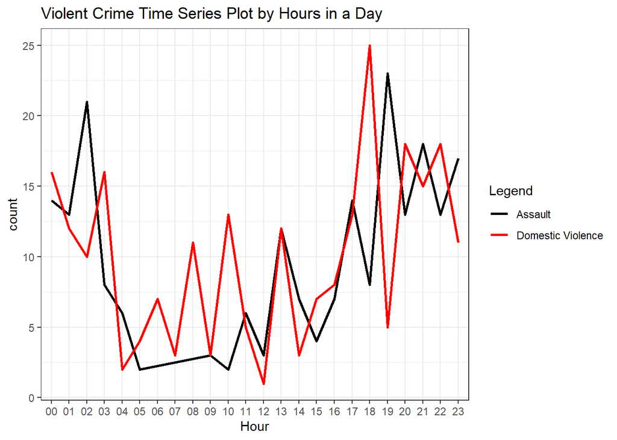

From the time series plot above we can see that Assault is most common in the evening and late at night having its biggest peaks in 19:00 and 02:00 whilst having its lowest points during the early in the morning at 05:00 and 10:00. For Domestic Violence we can see that it has its biggest peak in in the evening at 18:00 and at night at 22:00.

# A Closer Look: Drug Crime in Dallas

Similar to what we have done for violent crime we can create a map below to see if we can observe any pattern in the geographical locations of drug crime in Dallas.

[interactive chart not shown]

From the map above we can see that Drug Possession is mainly concentrated in central Dallas and reaching out to the outskirts of the city centre in a cobweb-like pattern. We can also break down the rate of drug crime into the different divisions to get a more objective look into which areas have higher cases of drug crime.

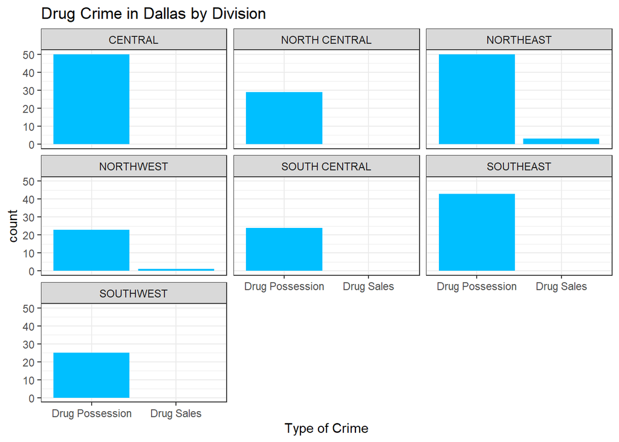

From looking at the plot above we can see that the eastern region of Dallas (CENTRAL, NORTHEAST and SOUTHEAST) have the highest count of Drug Possession and having nearly twice as many charges in individual western regions (NORTH CENTRAL, SOUTH CENTRAL, NORTHWEST and SOUTHWEST).

We can plot the rate of drug crime against the race of the suspects arrested below.

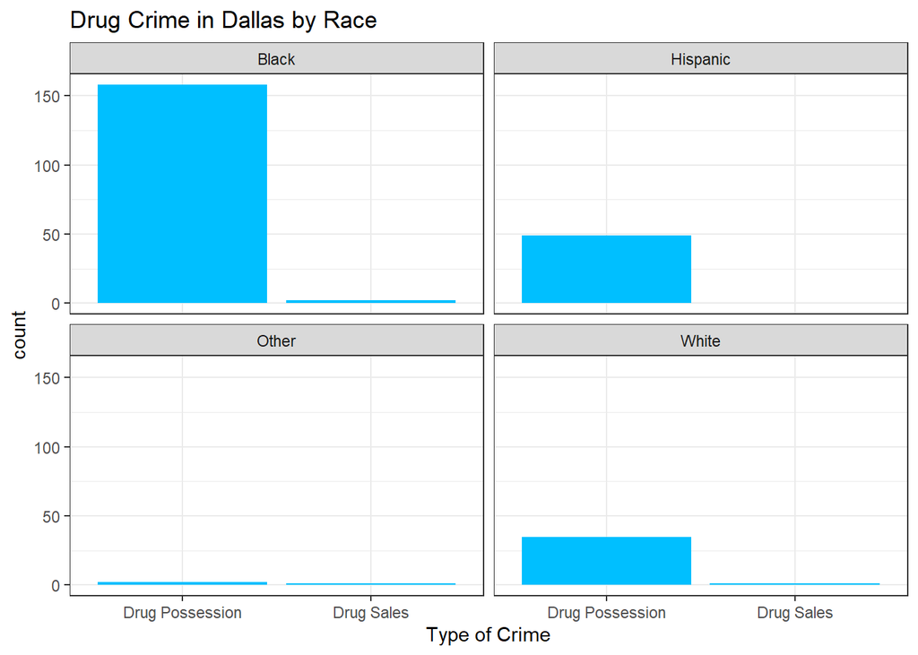

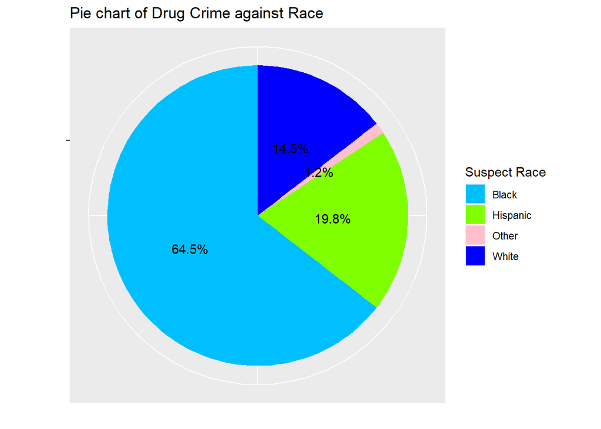

From the plot above we can see that Black suspects have the highest number of charges for Drug Possession followed by Hispanic suspects and White suspects.

From the pie chart above we can see that Black suspects have the biggest count of Drug Crime proportionally at 64.5% followed by Hispanic and White suspects at 19.8% and 14.5% respectively and Other at 1.2%.

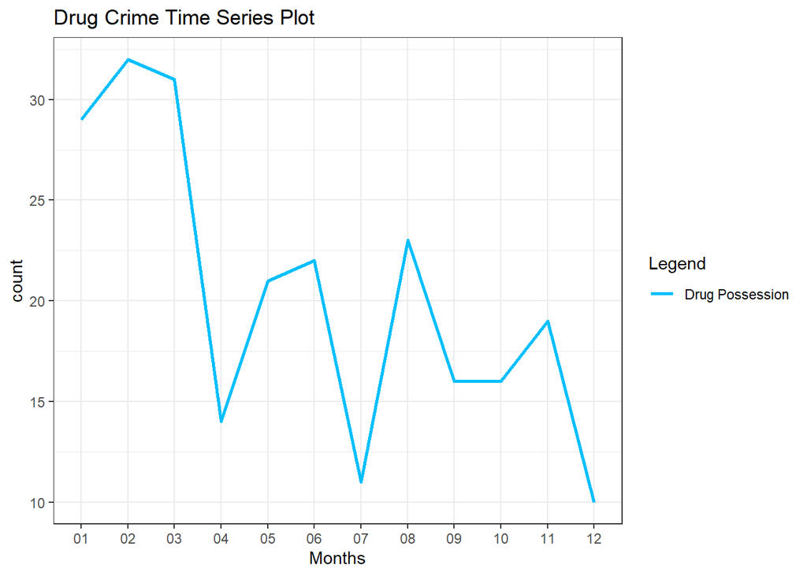

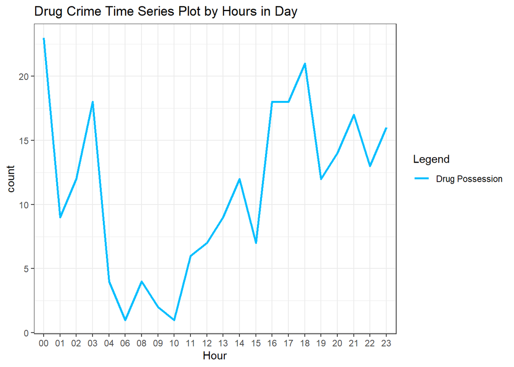

From the time series plot above we can see that Drug Possession is most common late in the night having its peak at midnight with smaller peaks in the evening as well. It is least common in the morning having its lowest count at 06:00 and 10:00.

# A Closer Look: Property Crime in Dallas

We can map the different locations of where property crime has occurred below.

[interactive chart not shown]

From the map above we can see that Trespassing (the highest type of property crime) being mainly concentrated in central Dallas and that Burglary (the second highest type of property crime) mainly occurring in central Dallas and stretching out to the southern outskirts of the city centre. For Vehicle Theft it is more spread evenly in the city with some concentration in the city centre and in the north. For Robbery/Theft it is well spread between the city centre and northern and eastern parts of the city.

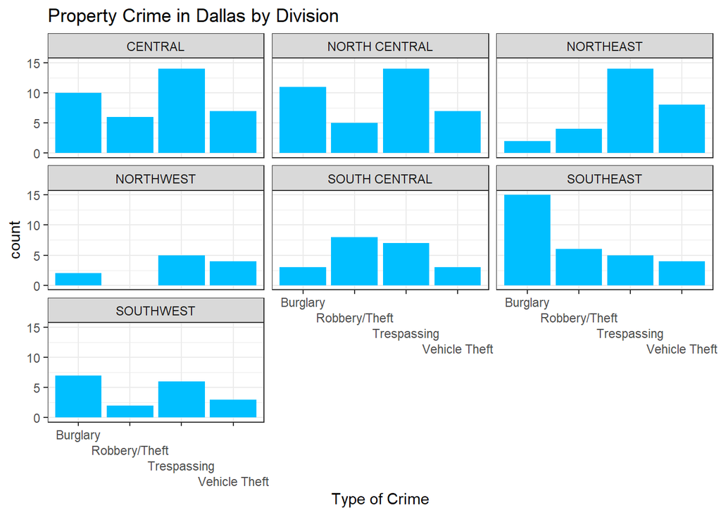

From the plot above we can see that burglary is most common in the central part of Dallas and southeastern regions of the city (NORTH CENTRAL, CENTRAL and SOUTHEAST). For Robbery/Theft it is evenly spread among the central and eastern divisions (NORTH CENTRAL, CENTRAL, SOUTH CENTRAL, NORTHEAST and SOUTHEAST). For Trespassing it is more common along the central and eastern divisions of the city (CENTRAL, NORTH CENTRAL and NORTHEAST). For Vehicle/Theft it is evenly spread across the different divisions with some slight increase in central and eastern divisions (NORTH CENTRAL, CENTRAL and NORTHEAST).

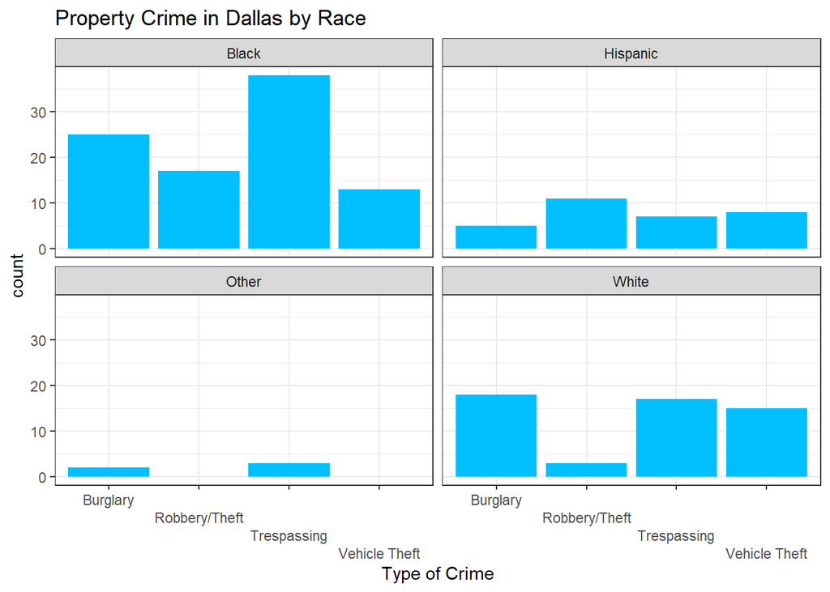

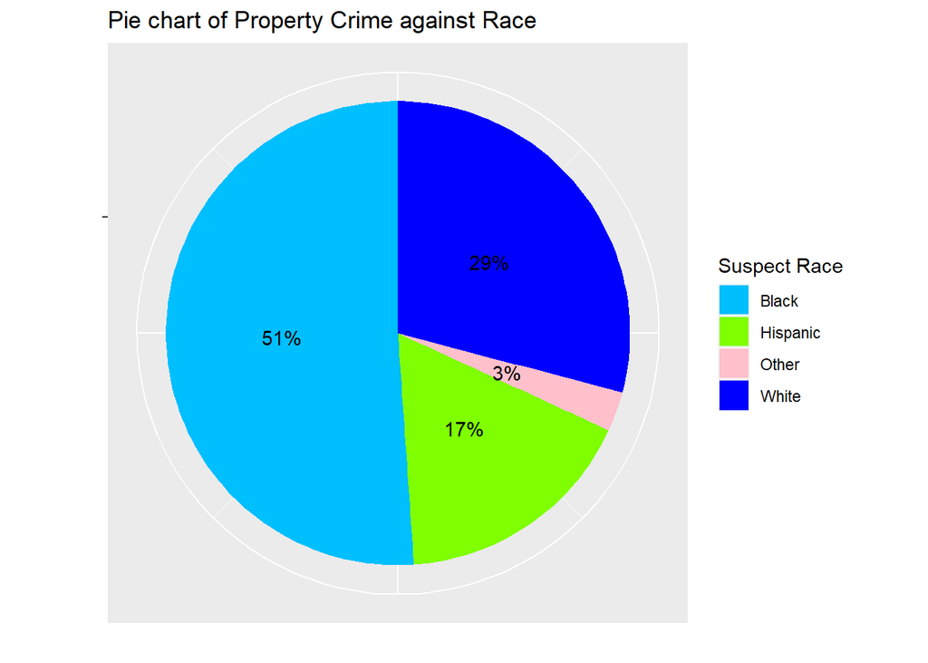

From the plot above we can see that the biggest perpetrators of Trespassing , Burglary and Robbery/Theft are Black suspects. We can also see that White suspects are the biggest perpetrators of Vehicle Theft followed closely behind by Black suspects.

From the pie chart we can see that Black suspects have the biggest count of Property Crime proportionally at 51% with White and Hispanic suspects at 29% and 17% respectively and Other at 3%.

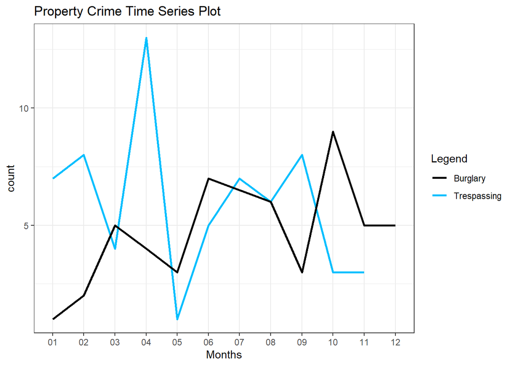

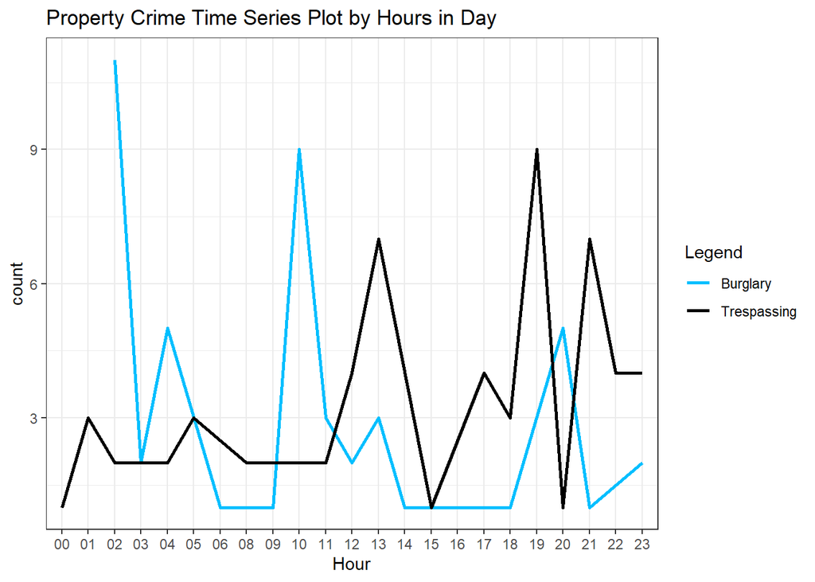

# A Closer Look: Traffic Crime in Dallas

We can map the different locations of where traffic crime has occurred below.

[interactive chart not shown]

From the map above we can see that DUI/DWI are most common in central Dallas and in western Dallas and slightly less common in the east. Traffic Violations are more common in Northern Dallas with a slight increase in the northwestern region of Dallas compared to the northeast.

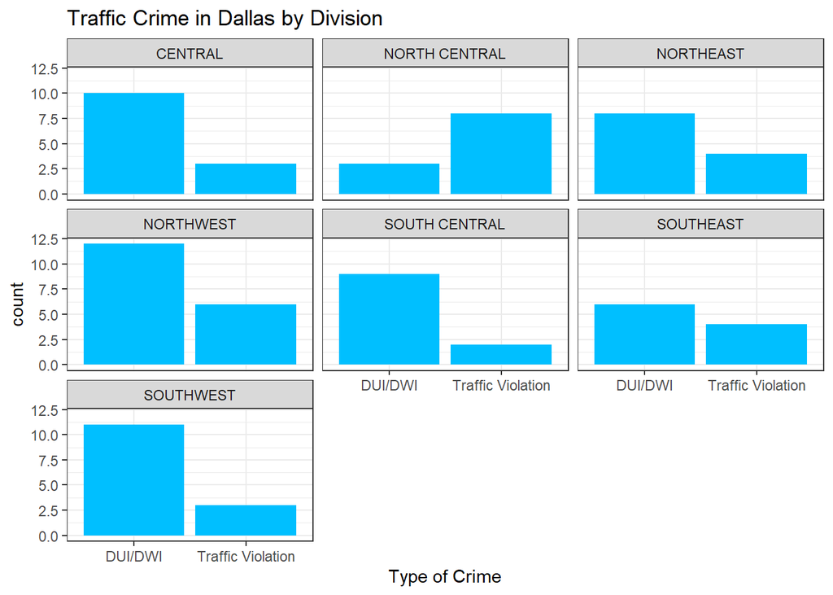

Looking at the plot above we can see that DUI/DWI offenses are mostly common in central and western divisions of Dallas (CENTRAL, SOUTH CENTRAL, NORTHWEST and SOUTHWEST) and slightly less common in the eastern divisions of Dallas (NORTHEAST and SOUTHEAST). From the plot above we can also see that Traffic Violations are most common in the northern and western divisions (NORTH CENTRAL and NORTHWEST) and are spread more evenly across the remaining divisions (CENTRAL, SOUTHWEST, SOUTH CENTRAL, NORTHEAST and SOUTHEAST).

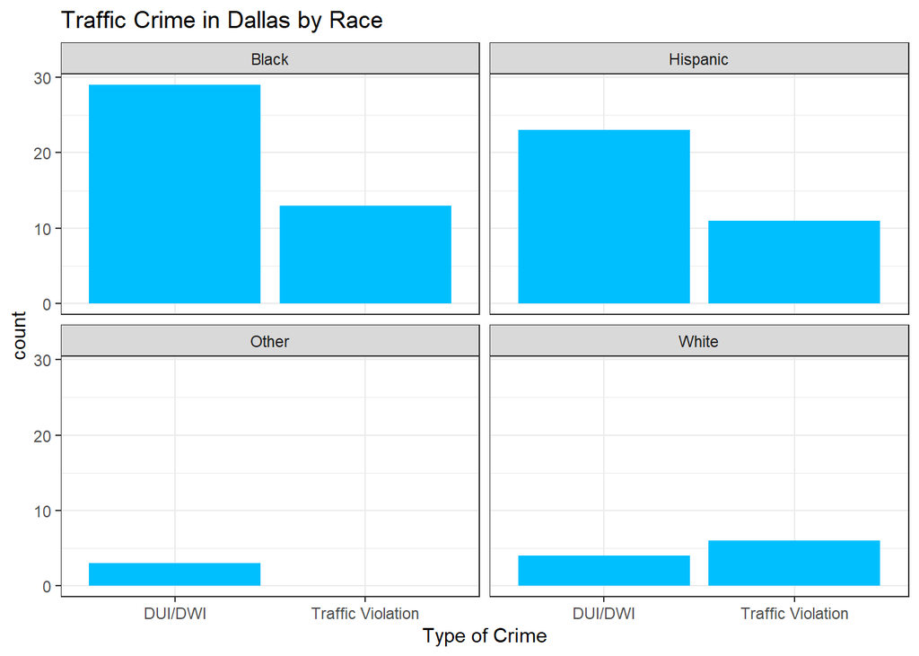

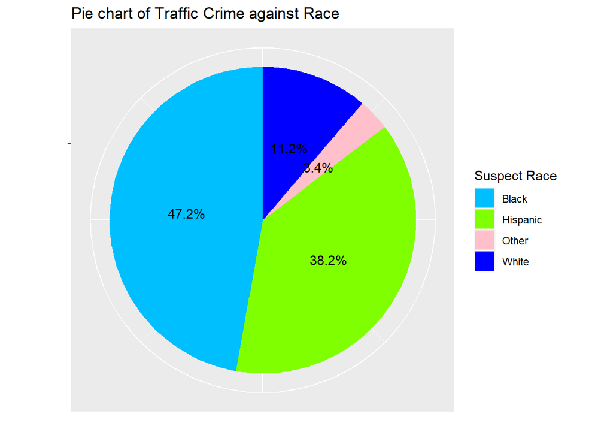

From the plot above we can see that Black and Hispanic suspects are the biggest perpetrators of DUI/DWI offenses with White suspects being last. Similarly for Traffic Violations Black and Hispanic suspects have the biggest count of offenses with Black suspects having slightly more than Hispanic suspects and White suspects being last.

From the pie chart above we can see that Black suspects have the biggest count of Traffic Crime proportionally at 47.2% with Hispanic and White suspects at 38.2% and 11.2% respectively with Other at 3.4%.

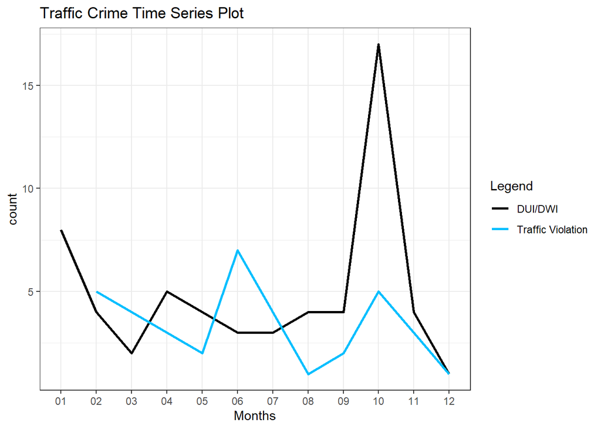

From the time series plot above we can see that for DUI/DWI it has a large peak in October and reaches its lowest point in the end of the year in December. For Traffic Violation it reaches its peaj in June and its lowest point in August and December.

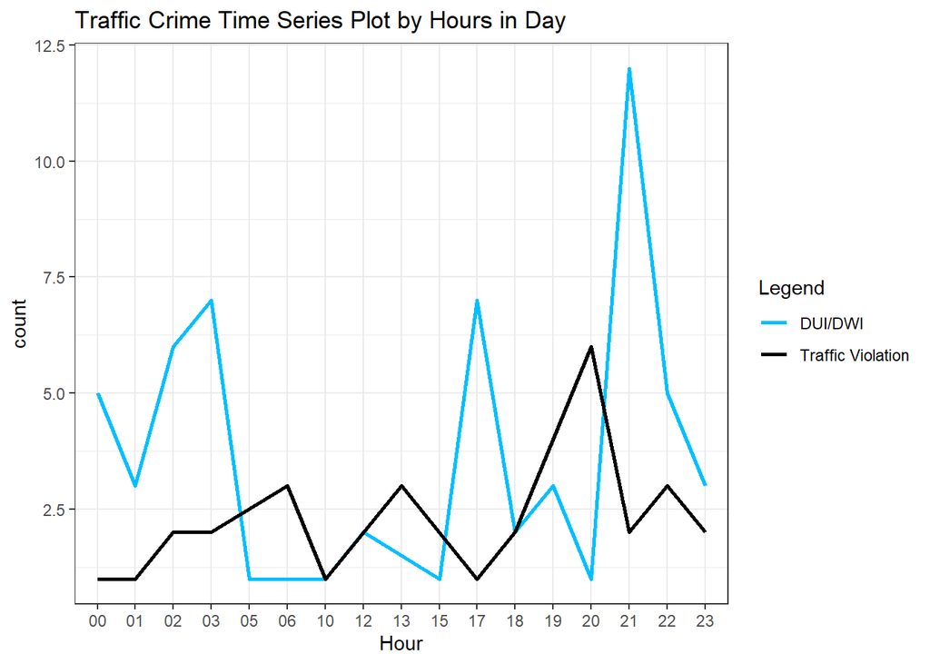

From the time series plot above we can see that for DUI/DWI it is most common at night having its peak at 21:00 and late at night and afternoon having smaller peaks at 03:00, 17:00 and 19:00 and being least common early in the morning and afternoon and evening having its smallest peaks in 05:00, 15:00 and 20:00. For Traffic Violation it is most common in the evening at 20:00 and having smaller peaks early in the morning, afternoon and at night at 06:00, 13:00 and 22:00. Traffic Violation is also least common early in the morning, in the afternoon and at night at 10:00, 17:00 and 21:00.